# STA 363 Project 1

Jason Hou

2022-09-12

#Abstract

#Section 1 Introduction and Data

```r
#Load all required packages
library(ggplot2)
library(broom)
library(gridExtra)
library(dplyr)
library(class)
library(tidyverse)
library(gridExtra)
```

```r
#Load dengue data
dengue<-read.csv("dengueData.csv")
```

```r
#Checking if NA exists in data set
sum(is.na(dengue))
```

```
## [1] 0
```

#Section 2 KNN ## KNN Example

```r
#Create a data set for demo
knnDemo<-data.frame("dengue_status"= dengue$Y,"Age"= dengue$Age, "Height"= dengue$Height)
```

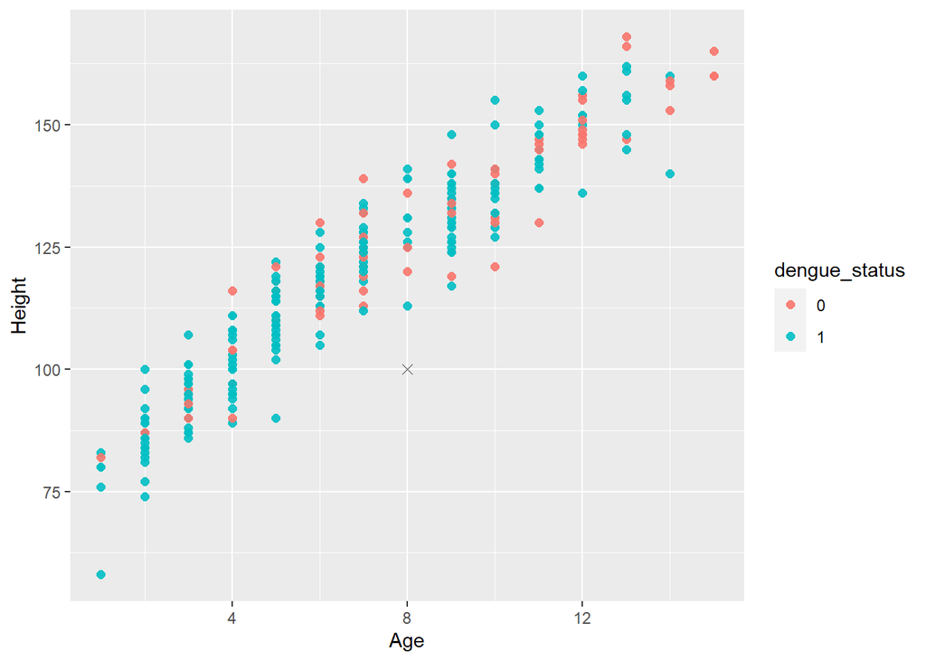

```r
example_data<-data.frame("Age"= rep(NA,1),"Height"=rep(NA,1))
example_data$Age[1]<-8
example_data$Height[1]<-100

SetForDemo<-SetForDemo%>%
  mutate(dengue_status=as.character(dengue_status))
#demoTest<-example_data%>%
 # mutate(dengue_status_test=as.character(dengue_status))
ggplot()+
  geom_point(data = SetForDemo,aes(x=Age,y=Height,col=dengue_status),size=2,alpha=0.9,shape=19)+
  geom_point(data =example_data,aes(x=Age,y=Height),size=2,alpha=0.9,shape=4)
```

Here we have a data point (a boy iwht height of 100cm and age of 8 year old). We look for the dengue status of the 3 nearest data point respect to this data point on the graph and check their dengue status, then we assign the dengue status that the majority of these 3 data points have as the predicted dengue status of this 8 year-old, 100cm boy.

##Demo KNN

### Split data in to 20% testing and 80% training

```r
q<-nrow(dengue)
#Set a seed for sampling
set.seed(363663)
manually_select<-sample(1:q,q*0.8,replace = "FALSE")
manual_train<-dengue[manually_select,]
manual_test<-dengue[-manually_select,]
storage8020<-data.frame("Predictions" = rep(NA,1146))
#Find rows with positive and negative result
    true1_split<-which(manual_test$Y == 1)
    true0_split<-which(manual_test$Y == 0)

#Compute the amount of rows corresponding to each result
    ntrue1_split<-length(true1_split)
    ntrue0_split<-length(true0_split)

storage_split<-data.frame("K"= rep(NA,50),"GeoMean"= rep(NA,50))

for(t in 1:50){
  storage_split$K[t]<-t
  k_preds_split<-knn(manual_train[,c(2,3,8,9)],manual_test[,c(2,3,8,9)],k=t,cl=manual_train$Y)
  storage8020$Predictions<-as.numeric(as.character(k_preds_split))



  sensitivity_split<-sum(k_preds_split[true1_split] == 1)/ntrue1_split

  specificity_split<-sum(k_preds_split[true0_split] == 0)/ntrue0_split
  storage_split$GeoMean[t]<-sqrt(sensitivity_split*specificity_split)
}
knitr::kable(table(storage8020$Predictions, manual_test$Y), caption= "Table 1: Confusion Matrix(80% Training & 20% Testing ) ", col = c("Not Dengue", "Dengue"))
```

Table 1: Confusion Matrix(80% Training & 20% Testing )

|  | Not Dengue | Dengue |
| --- | --- | --- |
| 0 | 122 | 87 |
| 1 | 226 | 711 |

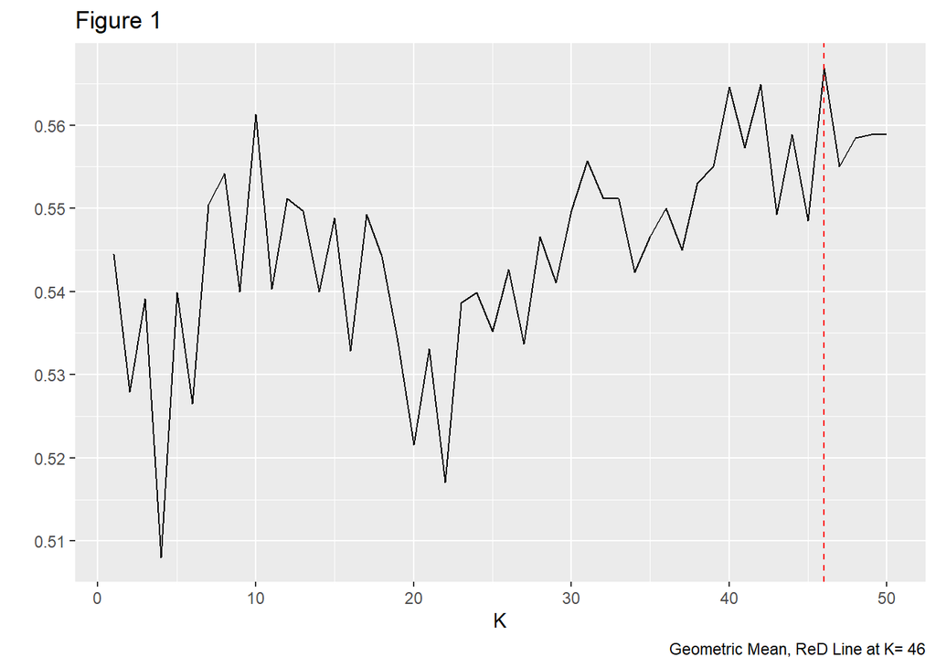

```r
#Create plot to find the best k for KNN
knnSplit<-ggplot(storage_split,aes(K,GeoMean))+
  geom_line()+
  labs(caption = paste("Geometric Mean, ReD Line at K=", which.max(storage_split$GeoMean)),title = "Figure 1",y = " ")+
  geom_vline(xintercept = which.max(storage_split$GeoMean),lty = 2,col="red")
knnSplit
```

```r
n<-nrow(knnActual)
nk<-50
storage<-data.frame("K"=rep(NA,nk),
                    "Sensitivity" = rep(NA,nk),
                    "Specificity" = rep(NA,nk),
                    "GeoMean" = rep(NA,nk))

#Set a seed for sampling and create a pool and set fold for K fold CV
set.seed(363663)
pool<-rep(1:10,573)

fold<-sample(pool,5726,replace = FALSE)

#Outer loop for incrementing k
for(k in 1:nk){
  storage$K[k]<-k

  storage_inner<-data.frame("YHat" = rep(NA,n))
  #Inner loop for 10 fold cv
  for(i in 1:10){
    #Find data in each fold
    infold<-which(fold == i)

    #Create training and testing sets
    Train_Dengue<-knnActual[-infold,]
    Test_Dengue<-knnActual[infold,]

    #Run Knn
    k_preds<-knn(Train_Dengue[,c(2,3,8,9)],Test_Dengue[,c(2,3,8,9)],k=k,cl=Train_Dengue$Y)

    #store results
    storage_inner$YHat[infold]<-as.numeric(as.character(k_preds))

    #Find rows with positive and negative result
    true1<-which(Test_Dengue$Y == 1)
    true0<-which(Test_Dengue$Y == 0)

    #Compute the amount of rows corresponding to each result
    ntrue1<-length(true1)
    ntrue0<-length(true0)
#Compute sensitivity and specificity, as well as GeoMean for determining the best value for k
sensitivity<-sum(k_preds[true1] == 1)/ntrue1
storage$Sensitivity[k]<-sensitivity
specificity<-sum(k_preds[true0] == 0)/ntrue0
storage$Specificity[k]<-specificity
storage$GeoMean[k]<-sqrt(sensitivity*specificity)

  }

}
```

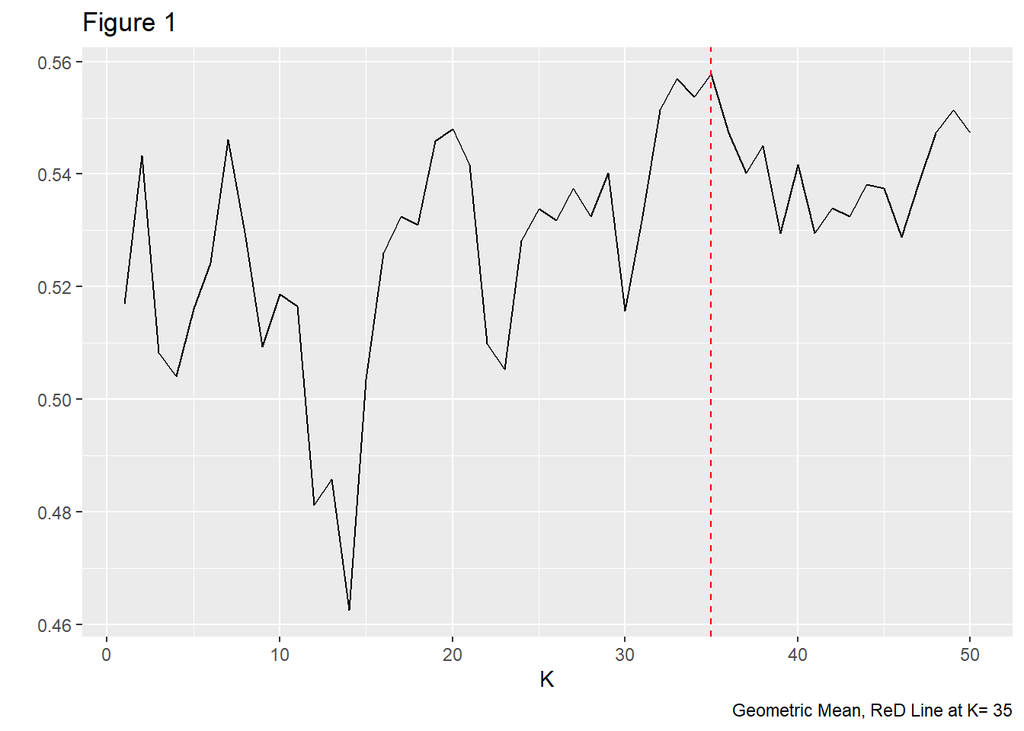

```r
#Create plot to find the best k for KNN
knnActualPlot<-ggplot(storage,aes(K,GeoMean))+
  geom_line()+
  labs(caption = paste("Geometric Mean, ReD Line at K=", which.max(storage$GeoMean)),title = "Figure 1",y = " ")+
  geom_vline(xintercept = which.max(storage$GeoMean),lty = 2,col="red")
#Show Plot
knnActualPlot
```

```r
#Set a seed for sampling
set.seed(363663)
#create storage for prediction result
storage_inner_trial<-data.frame("pred"=rep(NA,5726))
#run 10 fold knn with best k value = 35
 for(i in 1:10){

   #Find data in each fold
    infold<-which(fold == i)

    #Creating Training and testing set
    Train_Dengue<-knnActual[-infold,]
    Test_Dengue<-knnActual[infold,]
    #Run knn
    k_preds_best<-knn(Train_Dengue[,c(2,3,8,9)],Test_Dengue[,c(2,3,8,9)],k=35,cl=Train_Dengue$Y)
    #store result
    storage_inner_trial$pred[infold]<-as.numeric(as.character(k_preds))


 }
#Compute sensitivity and specificity,formating them
sensitivity2<-sum(k_preds[true1] == 1)/ntrue1
knitr::kable(sensitivity)
```

| x |
| --- |
| 0.8987654 |

```r
specificity2<-sum(k_preds[true0] == 0)/ntrue0


#Create confusion Matrix for the prediction with full dengue set

knitr::kable(table(storage_inner_trial$pred, dengue$Y), caption= "Table 2: Confusion Matrix of Predicting Dengue Status (10 Fold CV & KNN with K = 35)  ", col = c("Not Dengue", "Dengue"))
```

|  | Not Dengue | Dengue |
| --- | --- | --- |
| 0 | 315 | 654 |
| 1 | 1383 | 3374 |

Age, Daydisease, temperature and BMI are the only four included in the prediction. Body height and weight was dropped from prediction since they are highly correlated with BMI(according to BMI formula)and would create multicolinearity in the prediction.

## Section 3 Logistic Regression

#EDA

```r
ForEDA<-dengue
```

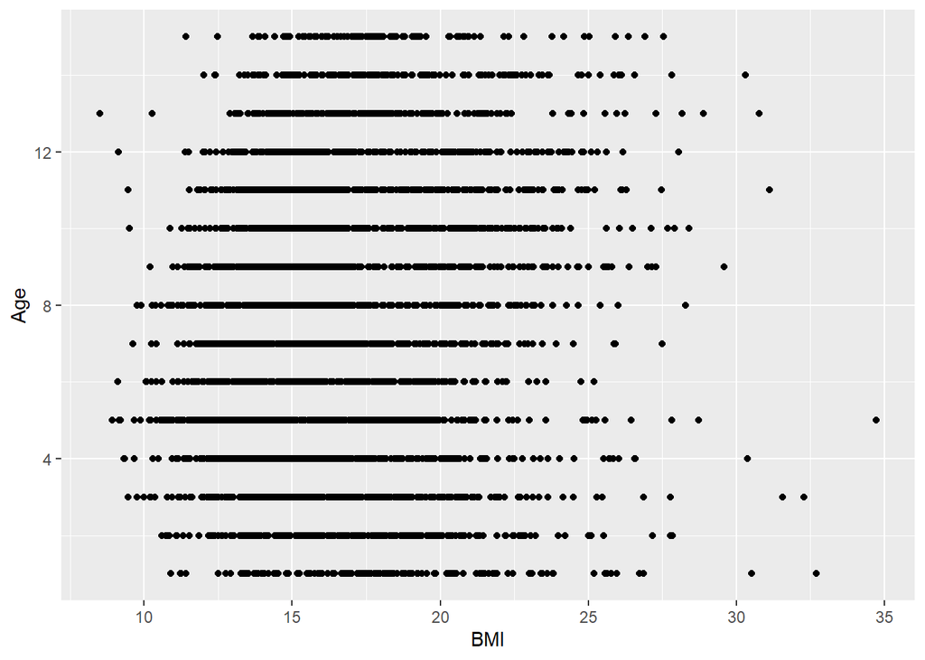

```r
AgeBMIDengue<-ggplot(data = dengue,aes(x=BMI,y=Age))+
  geom_point()
AgeBMIDengue
```

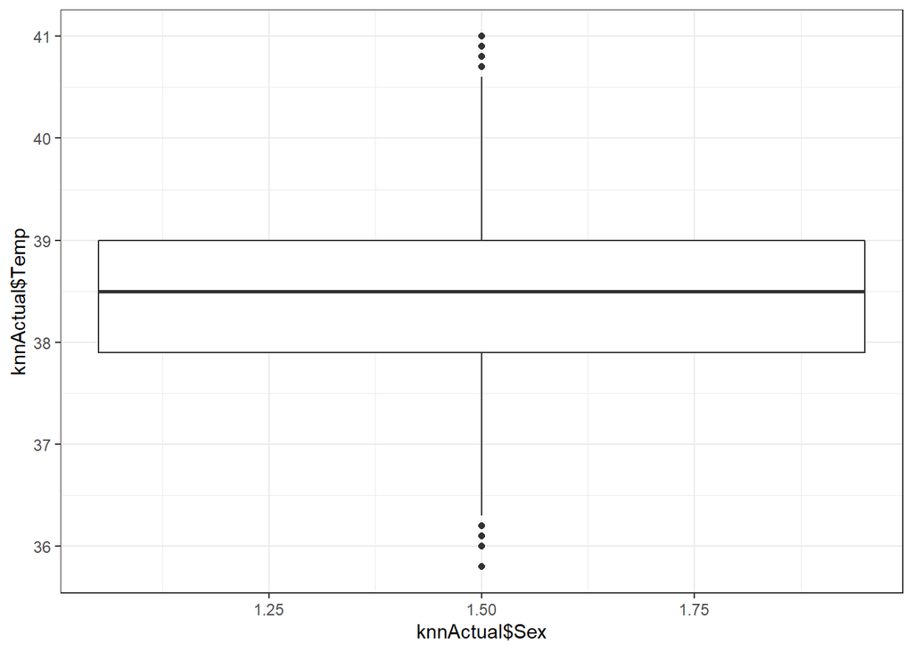

```r
ForEDA<-dengue
ForEDA$Sex=as.character(ForEDA$Sex)
BoxDengue<-ggplot(data=dengue,aes(x=knnActual$Sex,y=knnActual$Temp,fill=Temp))+
  theme_bw()+
  geom_boxplot()
BoxDengue
```

##Checking interaction

[output not shown]

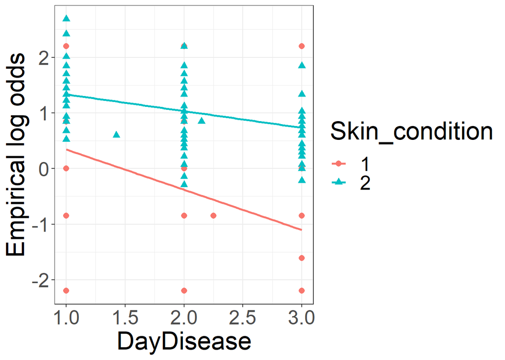

```r
dengue%>%
  mutate(DayDisease=dengue$DayDisease,
         Skin_condition=as.factor(dengue$Skin))%>%
  logodds_plot(100, "equal_size", x = "DayDisease", y = "Y",reg_formula = y ~ x, grouping = "Skin_condition")
```

```r
#Create a data set dedicated for checking condition and EDA
dengueForCheck<-dengue
```

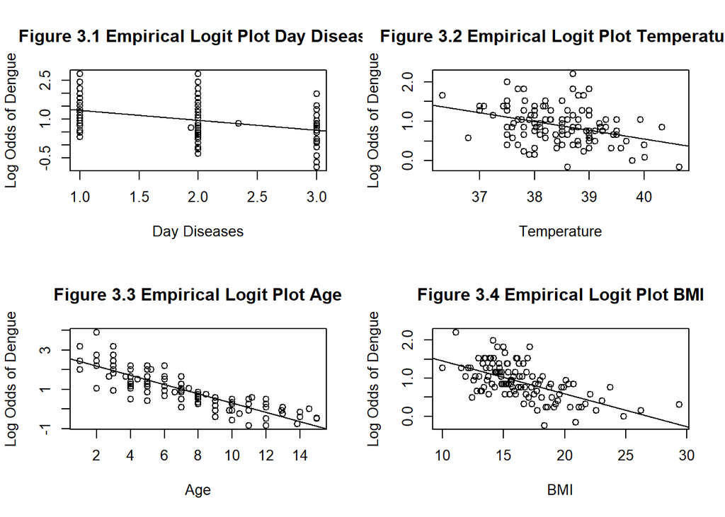

```r
#Display 4 graphs together
op<-par(mfrow=c(2,2))

#Checking linear relationship between log odds that Y=1 and four numeric Xi
logit_DayDisease<-emplogitPlot(x=dengueForCheck$DayDisease,y=dengueForCheck$Y,xlab = "Day Diseases",ylab = "Log Odds of Dengue",main = "Figure 3.1 Empirical Logit Plot Day Disease")

logit_Temp<-emplogitPlot(x=dengueForCheck$Temp,y=dengueForCheck$Y,xlab = "Temperature",ylab = "Log Odds of Dengue",main = "Figure 3.2 Empirical Logit Plot Temperature")

logit_Age<-emplogitPlot(x=dengueForCheck$Age,y=dengueForCheck$Y,xlab = "Age",ylab = "Log Odds of Dengue",main = "Figure 3.3 Empirical Logit Plot Age")

logit_BMI<-emplogitPlot(x=dengueForCheck$BMI,y=dengueForCheck$Y,xlab = "BMI",ylab = "Log Odds of Dengue",main = "Figure 3.4 Empirical Logit Plot BMI")
```

```r
#Checking correlations between variable to determine multicolinearity
correlation<-cor(dengueForCheck[,c(2,8:11)])
correlation_tr<-round(correlation,3)
knitr::kable(correlation_tr)
```

|  | Age | Temp | BMI | Height | Weight |
| --- | --- | --- | --- | --- | --- |
| Age | 1.000 | 0.012 | 0.171 | 0.945 | 0.847 |
| Temp | 0.012 | 1.000 | 0.041 | 0.023 | 0.034 |
| BMI | 0.171 | 0.041 | 1.000 | 0.149 | 0.561 |
| Height | 0.945 | 0.023 | 0.149 | 1.000 | 0.883 |
| Weight | 0.847 | 0.034 | 0.561 | 0.883 | 1.000 |

```r
#Set seed for sampling
set.seed(363663)
n<-nrow(knnActual)
storage_logistic<-data.frame("Predicted" = rep(NA,5726))

#Creating pools and set fold for K fold CV
logisticpool<-rep(1:10,573)

#Sampling for the pool, assign rows with fold number
logisticfold<-sample(logisticpool,5726,replace = FALSE)

#Subset a data set for training logistic model
logisticTotal<-knnActual[,c(1,2,4,8,9,11,12,13,14,15)]

#Create for loop to train the model
for(i in 1:10){
  inlogistic<-which(logisticfold==i)
  logisticTrain<-logisticTotal[-inlogistic,]
  logisticTest<-logisticTotal[inlogistic,]

  modelTrained<-glm(data=logisticTrain,family = binomial,Y~Sex+Vomiting+Temp+Age*Weight+BMI+Rash+Hepatomegaly)
  probabilities<-predict(modelTrained,newdata=logisticTest)
  predicted.Y<-ifelse(probabilities>0.5,"1","0")
  storage_logistic$Predicted[inlogistic]<-as.numeric(as.character(predicted.Y))

}
```

#Formatted Confusion Matrix of Prediction with logistic regression

```r
knitr::kable(table(storage_logistic$Predicted, knnActual$Y), caption= "Table 3: Confusion Matrix of Predicting Dengue Status (Logistic Regerssion & 10 Fold cv)  ", col = c("Not Dengue", "Dengue"))
```

Table 3: Confusion Matrix of Predicting Dengue Status (Logistic Regerssion & 10 Fold cv)

|  | Not Dengue | Dengue |
| --- | --- | --- |
| 0 | 937 | 891 |
| 1 | 761 | 3137 |

$$Specificity = \frac{937}{761+937}\approx
0.5518$$

## Section 4 Discussion